# Älykkäästi datasta käytäntöön: ostokäyttäytymisen keskeisten ajureiden arviointi GMM-pohjaisille segmenteille XGBoost-ennusteanalyysissa

Tässä projektissa on tarkoituksena selvittää kuinka erilaiset demografiset ja interaktio-muuttujat vaikuttavat asiakkaiden kuluttajatottumuksiin (ostetut tuotteet) datasta johdetuissa asiakassegmenteissä. Analyysissa käytetään Gaussian Mixture Model -mallia datasegmenttien luomiseen, XGBoost-mallia ennustearvojen laatimiseen kullekin segmentille, ja lopuksi SHAP-analyysia kunkin asiakassegmentin keskeisten ostoskäyttäytymistä ajavien tekijöiden selvittämiseen..Analyysi antaa tärkeää tietoa kulutustottumuksista ja siitä miten ryhmäkohtaiset taustamuuttujat vaikuttavat ostoskäyttäytymiseen.

Aluperäinen data sisältää päivittäistavarakaupan kuvitteellisia asiakastietoja aina demografisista muihin tyypillisiin interaktiotietoihin, kuten kulutustottumuksiin. Datassa erotellaan kulutustottumukset (viini-, liha-, kala-, hedelmä-, makeis- ja erikoistuotteiden kulutus), ostokerrat per ostokanava (kuten kivijalka, netti, katalogi) sekä kampanjoihin osallistumisaktiivisuus (5 kampanjaa) omiksi yhdistelmämuuttujiksi. Lisäksi analyysi sisältää demografisia muuttujia (ikä, perhetausta, koulutus, lapsien määrä), joita muokkaan soveltuvammaksi analyysia varten.

'Age', 'Income', 'Family_Size', 'Marital_Status', 'Education', 'Children', 'Days_as_Customer', 'Parent', 'Complain', 'Recency', 'Response', 'Campaigns', 'Num_Interaction', 'Products_Bought', 'Education_Encoded', 'Marital_Status_Encoded','Living_With'

**Analyysin vaiheet**

Analyysi jakautuu kuuteen päävaiheeseen: datan esikäsittely, GMM-klusterianalyysi (+ PCA-analyysi) sekä lopuksi suoritettavaan datan mallintamiseen XGBoost-mallilla sekä SHAP-analyysi. Lopuksi analysoin ja esitän klusterikohtaiset tulokset ja analysoin mallin käyttökelpoisuutta jatkokäyttöä varten.

```python
df2_predicted.info()
```

```
<class 'pandas.core.frame.DataFrame'>
Index: 2208 entries, 0 to 2239
Data columns (total 19 columns):
 #   Column                  Non-Null Count  Dtype
---  ------                  --------------  -----
 0   Education               2208 non-null   object
 1   Marital_Status          2208 non-null   object
 2   Income                  2208 non-null   float64
 3   Recency                 2208 non-null   int64
 4   Complain                2208 non-null   int64
 5   Response                2208 non-null   int64
 6   Living_With             2208 non-null   object
 7   Family_Size             2208 non-null   object
 8   Days_as_Customer        2208 non-null   int64
 9   Age                     2208 non-null   int64
 10  Children                2208 non-null   int64
 11  Parent                  2208 non-null   int64
 12  Products_Bought         2208 non-null   int64
 13  Campaigns               2208 non-null   int64
 14  Num_Interaction         2208 non-null   int64
 15  Education_Encoded       2208 non-null   int64
 16  Marital_Status_Encoded  2208 non-null   int64
 17  Clusters                2208 non-null   int64
 18  Predicted_Values        2208 non-null   float32
dtypes: float32(1), float64(1), int64(13), object(4)
memory usage: 400.9+ KB
```

## Tulokset

```
Bics-value for clusters:  6
```

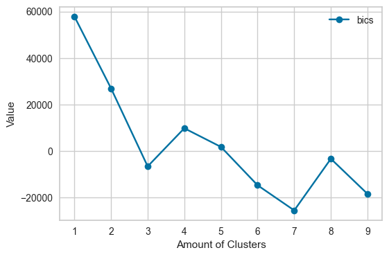

```python
bics_values = bics(df2)
```

PCA 3d -visualisoinnissa on nähtävissä 6:n klusterin jakautuminen datassa. Klustereiden epäsymmetrinen muoto ja hajonta viittaa datassa esiintyvään hajontaan, mikä on tyypillistä etenkin asiakasdatassa.

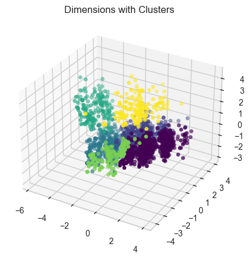

```python
df2_clusters, clustered_pipeline = clustering(df2, bics_values)
```

SHAP-analyysin tulokset jokaislle kuudelle klusterille erittelee XGBoost-mallin järjestää ennusteisiin vaikuttavat muuttujat tärkeysjärjestyksessä. SHAP-analyysissa tärkeimmät klusterikohtaiset muuttujat ovat niitä, jotka selittävät eniten kyseisen klusterin ostoskäyttäytymistä.

SHAP-analyysissa käytettiin yhdeksää eri muuttujaa: 'Income','Num_Interaction','Campaigns','Recency','Parent','Age','Response','Education_Encoded','Marital_Status_Encoded'

```
Shap for cluster 0
```

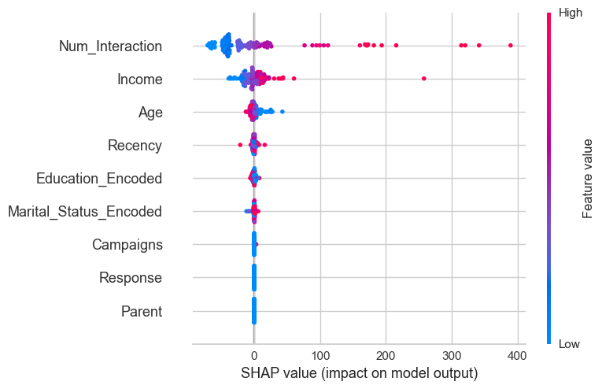

```
                        mean_abs_shap  mean_shap_direction
Num_Interaction             51.269638             0.967132
Income                      13.254637             0.785797
Age                          5.025620             0.419114
Recency                      1.827474            -0.078153
Education_Encoded            1.458388            -0.210468
Marital_Status_Encoded       0.873904            -0.163385
Campaigns                    0.177239            -0.029023
Parent                       0.000000             0.000000
Response                     0.000000             0.000000
Shap for cluster 1
```

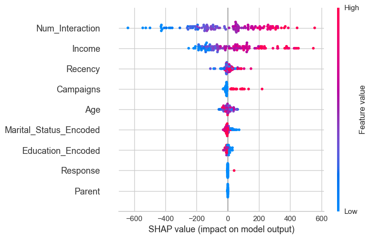

```
                        mean_abs_shap  mean_shap_direction
Num_Interaction            198.661621           -17.012264
Income                     144.813858            32.292686
Recency                     20.879831             6.871995
Campaigns                   20.750980             2.044585
Age                         16.942944             0.304911
Marital_Status_Encoded      12.284565             0.922930
Education_Encoded            8.475850             0.422637
Response                     1.125108            -0.500167
Parent                       0.481422            -0.481422
Shap for cluster 2
```

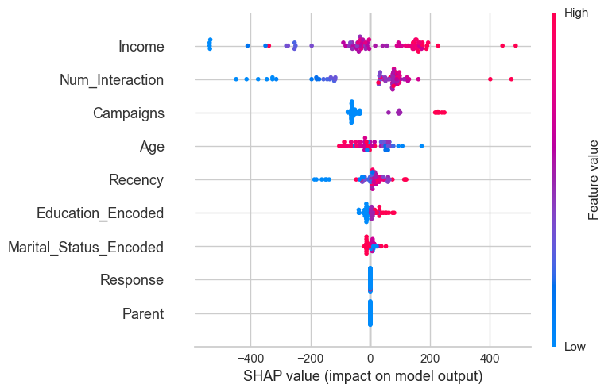

```
                        mean_abs_shap  mean_shap_direction
Income                     150.106827            -9.682792
Num_Interaction            125.227524             6.697883
Campaigns                   76.646393           -15.090769
Age                         46.818390             1.481388
Recency                     38.657932             2.840896
Education_Encoded           19.238359             3.459808
Marital_Status_Encoded      11.227856             1.039005
Parent                       0.000000             0.000000
Response                     0.000000             0.000000
Shap for cluster 3
```

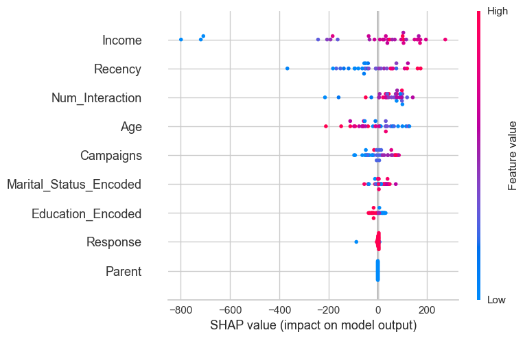

```
                        mean_abs_shap  mean_shap_direction
Income                     168.067856           -25.801615
Recency                     86.310913           -22.563267
Num_Interaction             72.008995            45.596985
Age                         64.598328           -10.589460
Campaigns                   40.309242             2.049948
Marital_Status_Encoded      22.824091            10.744860
Education_Encoded           17.621265            -0.386068
Response                     4.710112            -1.193777
Parent                       0.000000             0.000000
Shap for cluster 4
```

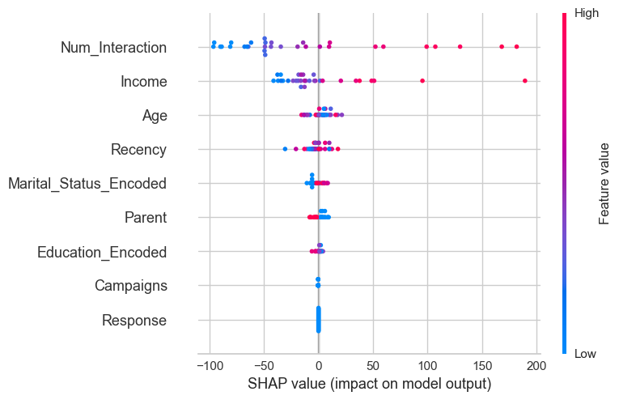

```
                        mean_abs_shap  mean_shap_direction
Num_Interaction             65.276253           -12.408198
Income                      29.946737             1.172952
Age                          7.014909             2.013273
Recency                      6.903447            -2.103042
Marital_Status_Encoded       4.748230            -1.466792
Parent                       4.280282             0.772989
Education_Encoded            1.752822             0.604664
Campaigns                    0.340061            -0.340061
Response                     0.000000             0.000000
Shap for cluster 5
```

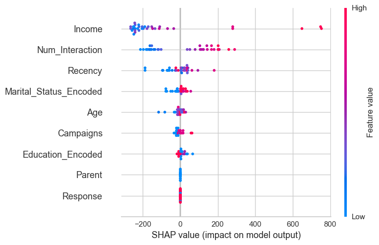

```
                        mean_abs_shap  mean_shap_direction
Income                     250.126007           -90.753548
Num_Interaction            155.567810             7.485852
Recency                     50.624966            -8.951815
Marital_Status_Encoded      22.907085            -6.124897
Age                         17.337999            -8.757015
Campaigns                   15.656151            -5.728805
Education_Encoded           11.663575             5.580661
Parent                       0.042383            -0.042383
Response                     0.000000             0.000000
```

```python
shap_value_analysis(models, X_tests)
```

### Asiakassegmentit

Asiakassegmentit jakautuvat analyysin perusteella kuuteen eri klusteriin. Alla taulukossa on laskettu lukumäärät ja keskiarvot keskeisille muuttujille: tulot, kampanjat, ostoskerrat, ostetut tuotteet - mitä tässä projektissa myös tutkittiin. Asiakassegmenttikohtaiset ennusteet on myös lisätty mukaan taulukkoon (Predicted_Values), jotka viitaavat ostettuihin tuotteisiin (€ keskiarvo).

```python
df2_predicted.groupby('Clusters')[['Income','Campaigns','Num_Interaction','Products_Bought','Predicted_Values']].agg(['count','mean']).round(2)
```

| Clusters | Income count | Income mean | Campaigns count | Campaigns mean | Num_Interaction count | Num_Interaction mean | Products_Bought count | Products_Bought mean | Predicted_Values count | Predicted_Values mean |
| --- | --- | --- | --- | --- | --- | --- | --- | --- | --- | --- |
| 0 | 711 | 34653.79 | 711 | 0.04 | 711 | 7.86 | 711 | 88.99 | 711 | 89.129997 |
| 1 | 649 | 60254.29 | 649 | 0.21 | 649 | 20.16 | 649 | 745.50 | 649 | 736.289978 |
| 2 | 362 | 73257.06 | 362 | 0.38 | 362 | 19.37 | 362 | 1212.28 | 362 | 1208.300049 |
| 3 | 166 | 75259.74 | 166 | 1.42 | 166 | 20.28 | 166 | 1485.49 | 166 | 1510.750000 |
| 4 | 151 | 29066.48 | 151 | 0.06 | 151 | 8.03 | 151 | 130.84 | 151 | 128.320007 |
| 5 | 169 | 45200.51 | 169 | 0.65 | 169 | 15.28 | 169 | 513.96 | 169 | 496.459991 |

```python
df2_predicted.groupby('Clusters')[['Income','Age','Marital_Status_Encoded','Family_Size','Children','Education_Encoded']].agg(['mean']).round(2)
```

| Clusters | Income mean | Age mean | Marital_Status_Encoded mean | Family_Size mean | Children mean | Education_Encoded mean |
| --- | --- | --- | --- | --- | --- | --- |
| 0 | 34653.79 | 53.35 | 3.00 | 3.21519 | 1.51 | 1.61 |
| 1 | 60254.29 | 60.13 | 3.12 | 2.850539 | 1.15 | 1.76 |
| 2 | 73257.06 | 58.76 | 2.99 | 1.676796 | 0.00 | 1.69 |
| 3 | 75259.74 | 54.51 | 2.45 | 1.427711 | 0.00 | 1.83 |
| 4 | 29066.48 | 47.81 | 2.17 | 1.788079 | 0.40 | 1.07 |
| 5 | 45200.51 | 55.43 | 2.78 | 2.840237 | 1.29 | 1.86 |

**1. klusteri (0) :** suurin (711), matalatuloinen ryhmä (mediaani 34643€), lapsia noin 1.51, keskimäärin kolmen henkilön talous, keskimäärin matalasti koulutettu, asioi ja kuluttaa vähiten (7.86 ostoskertaa / ~ 89€), ei hyödynnä kampanjoita.

- Tämän klusterin käyttäytymistä selittää eniten asioinnin määrä (Num_Interaction), sen jälkeen tulot ja asiakkaiden ikä.
- Mallin selitysaste tälle klusterille on 0.89 pienellä neliölliselä keskivirheellä (33), myös systeeminen virhe (-2.7) ja vaihtelu (33) segmentin sisällä jäävät pieniksi tehden mallista luotettavan ennustearvoja ja muuttujia arvioidessa tälle klusterille.

**2. klusteri (1) :** toiseksi suurin klusteri (649), keskituloinen yläluokka (mediaani 60432€), lapsia noin 1.15, keskimäärin vajaa 3:hlön talous, keskimäärin matalasti koulutettu, asioi toiseksi eniten (20.16 kertaa / ~ 745€), mutta ostaa vähemmän, kampanja-aktiivisuus keskimäärin noin 0.20 kampanjaa.

- Tässä klusterissa selittäviä muuttujia ovat etupäässä asioinnin määrä (198 yksikköä, suuri merkitys), sekä tulot (144 yksikköä) ja asioinnista kulunut aika (recency).
- Selitysaste kuitenkin jää 0.61 suurella neliöidyllä keskivirhellää mikä näkyy myös suurempana virheenä ja varianssina, joten mallin kykyyn ennustaa voi suhtautua varauksella.

**3. klusteri (2):** keskikokoinen (362), tuloiltaan korkeinta luokkaa (mediaani 74207€), lapseton, keskimäärin kahden hengen talous, keskimääräisesti matalasti koulutettu, asioi keskimäärin 19.37 kertaa ja kuluttaa toiseen klusteriin nähden enemmän (noin 1212€), kampanja-aktiivisuus 0.38.

- Klusterin ostoskäyttäytymistä selittävät eniten tulot (150 yksikköä). Ostoskertojen määrä (125 yksikköä) on seuraaavaksi eniten tulosta selittävä tekijä. Kolmanneksi tärkein muuttuja tässä klusterissa on kampanjat (76 yksikköä).
- Mallin selitysate jää kuitenkin pieneksi (0.47) suurella neliöllisellä keskivirheellä, mikä näkyy suuressa vaihtelussa, joten malli ei tarjoa kovin luotettavaa ennustearvoa.

**4. klusteri (3):** pieni klusteri (166), tuloiltaan korkeinta luokkaa (mediaani 78738€), lapseton, perhekoko keskimäärin 2 hlöä, mutta useimmiten sinkkutalous (moodi), keskimäärin korkeammin koulutettu suhteessa muihin (1.83), ostokerrat ja -määrät korkeimpia (~ 20 ostoskertaa / ~1485€), korkein kampanja-aktiivisuus arvolla 1.42.

**6. klusteri(5):** kooltaan pieni (169), keskimäärin korkeimmin koulutettu, tuloiltaan alempaa keskiluokkaa (mediaani 42207€), useammin naimisissa oleva, noin 1.3:n lapsen perhe, jonka kulutus 513€ (15 ostoskertaa), kampanja-aktiivisuus keskimäärin 0.65 kampanjakertaa.

- Tulot selittävät todella voimakkaasti tämän klusterin toimintaa (250 yksikköä). Kuten muissakin klustereissa, ostokerrat selittävät myös voimakkaasti ennustearvoa (155 yksikköä) ja asioinnista kulunut aika (50 yksikköä).
- Mallin selitysaste suhteellisen korkea, 0.825, mutta neliöity keskivirhe nousee 87:ään ja vaihtelu 207:ään, joten mallin luotettavuus jää kohtalaiseksi.

Analyysin ulkopuolelle jäi kolme ääriarvoa, joilla ei ole juurikaan merkitystä analyysin lopputulosten kannalta.

```python
income_outliers
```

|  | Education | Marital_Status | Income | Recency | Complain | Response | Living_With | Family_Size | Days_as_Customer | Age | Children | Parent | Products_Bought | Campaigns | Num_Interaction | Education_Encoded | Marital_Status_Encoded |
| --- | --- | --- | --- | --- | --- | --- | --- | --- | --- | --- | --- | --- | --- | --- | --- | --- | --- |
| 21 | Graduation | Married | 2447.0 | 42 | 0 | 0 | Partner | 3 | 4721 | 46 | 1 | 1 | 1730 | 0 | 43 | 1 | 4 |
| 1245 | Graduation | Divorced | 1730.0 | 65 | 0 | 0 | Alone | 1 | 4224 | 54 | 0 | 0 | 8 | 0 | 15 | 1 | 2 |
| 2233 | Graduation | Together | 666666.0 | 23 | 0 | 0 | Partner | 3 | 4574 | 48 | 1 | 1 | 62 | 0 | 11 | 1 | 3 |

### Johtopäätökset

Datasegmentit voidaan jakaa keskimäärin kolmeen eri kategoriaan tulojen mukaan:

- alhaisen tulostason ryhmä (noin +/- 30000€),
- keskituloiset, joissa matalan (~ 45000€) ja korkean tulotason (~60000€) alaryhmät sekä
- korkeatuloiset, jossa tulotaso on keskimäärin 74000€.

XGBoostin antamien ennusteisiin (predicted_values) tulee kuitenkin suhtautua varauksella, vaikkakin SHAP-analyysi tarjoaa oleellista tietoa kunkin klusterin kannalta tärkeistä ostoskäyttäytymistä ohjaavista tekijöistä.

Yhteiset selittävät muuttujat analyysissa olivat tulot, ostokertojen määrä ja jaetusti ikä ja asioinnista kulunut aika. Klusteri nro 3:ssa kampanjat vaikuttivat kolmanneksi voimakkaammin ostokäyttäytymiseen. Kampanjoiden hyödyntäminen vaikuttaakin olevan aktiivista etenkin suurissa tuloluokissa yleensäkin, ja ne myös vaikuttavat olevan yhteydessä ostoskertojen frekvenssiin ja kulutuksen suuruuteen. Etenkin lapsettomat, korkeatuloiset sinkut (segmentti 4) ovat kampanjoiden kuuma ryhmä. Tärkeää olisi siis miettiä sitä, onko kampanjoita syytä personoida alhaisemmille tuloluokille asiakasaktiivisuuden lisäämiseksi, koska ne ovat volyymiltaan suuria vaikkakin ostovoimaltaan heikkoja.